# BANKNOTE_CLASSIFICATION-SVM-RF

# Preface

We will exlore the behavior of support vector classifiers `SVC` and `SVMs` on our familiar `banknote authentication dataset` from UCI ML archive.

# Banknote authentication

This dataset presents an example of classification problem (authentic vs. counterfeit bank notes) using continuous predictors derived from image processing. More details about underlying data can be found in corresponding [dataset description](http://archive.ics.uci.edu/ml/datasets/banknote+authentication) at UCI ML website.

Loading the data, `data_banknote_authentication.txt` with the following attributes. The first $\textbf{four attributes}$ are used as $\textbf{predictors}$ to classify the outcome (authenic or counterfeit) and is presented by the $\textbf{fifth attribute as "Class"}$:

1.$\textbf{Var.W}$ : variance of Wavelet Transformed image (continuous)

2.$\textbf{Skew.W}$ : skewness of Wavelet Transformed image (continuous)

3.$\textbf{Curt.W}$ : curtosis of Wavelet Transformed image (continuous)

4.$\textbf{Entropy}$ : entropy of image (continuous)

5.$\textbf{Class}$ : class (integer)

```r
bank.N <- read.table("data_banknote_authentication.txt",sep=",")
colnames(bank.N) <- c("Var.W","Skew.W","Curt.W","Entropy", "Class")
# Checking the "Predictors" summary
summary(bank.N[,1:4])
```

```
##      Var.W             Skew.W            Curt.W           Entropy
##  Min.   :-7.0421   Min.   :-13.773   Min.   :-5.2861   Min.   :-8.5482
##  1st Qu.:-1.7730   1st Qu.: -1.708   1st Qu.:-1.5750   1st Qu.:-2.4135
##  Median : 0.4962   Median :  2.320   Median : 0.6166   Median :-0.5867
##  Mean   : 0.4337   Mean   :  1.922   Mean   : 1.3976   Mean   :-1.1917
##  3rd Qu.: 2.8215   3rd Qu.:  6.815   3rd Qu.: 3.1793   3rd Qu.: 0.3948
##  Max.   : 6.8248   Max.   : 12.952   Max.   :17.9274   Max.   : 2.4495
```

```r
# detecting number of ZEROs versus ONEs on the Outcome, "Class" attribute
bank.N$Class <- factor(bank.N$Class)
summary(bank.N[,5])
```

```
##   0   1
## 762 610
```

```r
# The total number of Zeros and Ones are accounted for: 762 + 610 = 1372, all the data has been classified as Authenic or Counterfeit.
dim(bank.N)
```

```
## [1] 1372    5
```

Here we will use SVM implementation available in library `e1071` to fit classifiers with linear and `radial` and `polynomial` kernels. We then compare their relative performance as well as to that of random forest and KNN.

# Problem 1 : support vector classifier (i.e. using linear kernel)

Use `svm` from library `e1071` with `kernel="linear"` to fit classifier (e.g. ISLR Ch.9.6.1) to the entire banknote authentication dataset setting parameter `cost` to 0.001, 1, 1000 and 1000000. Describe how this change in parameter `cost` affects model fitting process in terms of: – Its outcome – Number of support vectors and its implication – Explain why change in `cost` value impacts number of support vectors

Cost = 0.001

```r
svm.fit.R <- svm(Class~.,data=bank.N,kernel="linear",cost=0.001,scale=FALSE)
summary(svm.fit.R)
```

```
##
## Call:
## svm(formula = Class ~ ., data = bank.N, kernel = "linear", cost = 0.001,
##     scale = FALSE)
##
##
## Parameters:
##    SVM-Type:  C-classification
##  SVM-Kernel:  linear
##        cost:  0.001
##       gamma:  0.25
##
## Number of Support Vectors:  409
##
##  ( 204 205 )
##
##
## Number of Classes:  2
##
## Levels:
##  0 1
```

```r
pred <- predict(svm.fit.R, subset(bank.N, select=-Class))
confusionMatrix(pred, bank.N$Class)
```

```
## Confusion Matrix and Statistics
##
##           Reference
## Prediction   0   1
##          0 735   0
##          1  27 610
##
##                Accuracy : 0.9803
##                  95% CI : (0.9715, 0.987)
##     No Information Rate : 0.5554
##     P-Value [Acc > NIR] : < 2.2e-16
##
##                   Kappa : 0.9603
##  Mcnemar's Test P-Value : 5.624e-07
##
##             Sensitivity : 0.9646
##             Specificity : 1.0000
##          Pos Pred Value : 1.0000
##          Neg Pred Value : 0.9576
##              Prevalence : 0.5554
##          Detection Rate : 0.5357
##    Detection Prevalence : 0.5357
##       Balanced Accuracy : 0.9823
##
##        'Positive' Class : 0
##
```

cost = 1

```r
svm.fit.R <- svm(Class~.,data=bank.N,kernel="linear",cost=1,scale=FALSE)
summary(svm.fit.R)
```

```
##
## Call:
## svm(formula = Class ~ ., data = bank.N, kernel = "linear", cost = 1,
##     scale = FALSE)
##
##
## Parameters:
##    SVM-Type:  C-classification
##  SVM-Kernel:  linear
##        cost:  1
##       gamma:  0.25
##
## Number of Support Vectors:  43
##
##  ( 23 20 )
##
##
## Number of Classes:  2
##
## Levels:
##  0 1
```

```r
pred <- predict(svm.fit.R, subset(bank.N, select=-Class))
confusionMatrix(pred, bank.N$Class)
```

```
## Confusion Matrix and Statistics
##
##           Reference
## Prediction   0   1
##          0 752   5
##          1  10 605
##
##                Accuracy : 0.9891
##                  95% CI : (0.982, 0.9939)
##     No Information Rate : 0.5554
##     P-Value [Acc > NIR] : <2e-16
##
##                   Kappa : 0.9779
##  Mcnemar's Test P-Value : 0.3017
##
##             Sensitivity : 0.9869
##             Specificity : 0.9918
##          Pos Pred Value : 0.9934
##          Neg Pred Value : 0.9837
##              Prevalence : 0.5554
##          Detection Rate : 0.5481
##    Detection Prevalence : 0.5517
##       Balanced Accuracy : 0.9893
##
##        'Positive' Class : 0
##
```

cost = 1000

```r
svm.fit.R <- svm(Class~.,data=bank.N,kernel="linear",cost=1000,scale=FALSE)
summary(svm.fit.R)
```

```
##
## Call:
## svm(formula = Class ~ ., data = bank.N, kernel = "linear", cost = 1000,
##     scale = FALSE)
##
##
## Parameters:
##    SVM-Type:  C-classification
##  SVM-Kernel:  linear
##        cost:  1000
##       gamma:  0.25
##
## Number of Support Vectors:  20
##
##  ( 11 9 )
##
##
## Number of Classes:  2
##
## Levels:
##  0 1
```

```r
pred <- predict(svm.fit.R, subset(bank.N, select=-Class))
confusionMatrix(pred, bank.N$Class)
```

```
## Confusion Matrix and Statistics
##
##           Reference
## Prediction   0   1
##          0 752   7
##          1  10 603
##
##                Accuracy : 0.9876
##                  95% CI : (0.9802, 0.9928)
##     No Information Rate : 0.5554
##     P-Value [Acc > NIR] : <2e-16
##
##                   Kappa : 0.9749
##  Mcnemar's Test P-Value : 0.6276
##
##             Sensitivity : 0.9869
##             Specificity : 0.9885
##          Pos Pred Value : 0.9908
##          Neg Pred Value : 0.9837
##              Prevalence : 0.5554
##          Detection Rate : 0.5481
##    Detection Prevalence : 0.5532
##       Balanced Accuracy : 0.9877
##
##        'Positive' Class : 0
##
```

cost = 1000000

```r
svm.fit.R <- svm(Class~.,data=bank.N,kernel="linear",cost=1000000,scale=FALSE)
summary(svm.fit.R)
```

```
##
## Call:
## svm(formula = Class ~ ., data = bank.N, kernel = "linear", cost = 1e+06,
##     scale = FALSE)
##
##
## Parameters:
##    SVM-Type:  C-classification
##  SVM-Kernel:  linear
##        cost:  1e+06
##       gamma:  0.25
##
## Number of Support Vectors:  9
##
##  ( 5 4 )
##
##
## Number of Classes:  2
##
## Levels:
##  0 1
```

```r
pred <- predict(svm.fit.R, subset(bank.N, select=-Class))
confusionMatrix(pred, bank.N$Class)
```

```
## Confusion Matrix and Statistics
##
##           Reference
## Prediction   0   1
##          0 742   9
##          1  20 601
##
##                Accuracy : 0.9789
##                  95% CI : (0.9698, 0.9858)
##     No Information Rate : 0.5554
##     P-Value [Acc > NIR] : < 2e-16
##
##                   Kappa : 0.9573
##  Mcnemar's Test P-Value : 0.06332
##
##             Sensitivity : 0.9738
##             Specificity : 0.9852
##          Pos Pred Value : 0.9880
##          Neg Pred Value : 0.9678
##              Prevalence : 0.5554
##          Detection Rate : 0.5408
##    Detection Prevalence : 0.5474
##       Balanced Accuracy : 0.9795
##
##        'Positive' Class : 0
##
```

Use `tune()` function from library `e1071` (see ISLR Ch.9.6.1 for details and examples of usage) to determine approximate value of cost (in the range between 0.1, 1, 10, 100) that yields the lowest error when using `tune()`! Setup a resampling procedure repeatedly splitting entire dataset into training and test, using training data to `tune()` cost value and test dataset to estimate classification error. Report and discuss test errors on the selected values of `cost`.

```r
error <- NULL
tr_idx  <- sample(nrow(bank.N),round(0.8*nrow(bank.N),digits=0)); length(tr_idx)
```

```
## [1] 1098
```

```r
ts_idx  <- -tr_idx
bank.N_tr <- bank.N[tr_idx, ]; dim(bank.N_tr)
```

```
## [1] 1098    5
```

```r
bank.N_ts <- bank.N[ts_idx, ]; dim(bank.N_ts)
```

```
## [1] 274   5
```

```r
bank.N_tr_f.tor <- bank.N[tr_idx, "Class"]
bank.N_ts_f.tor <- bank.N[ts_idx, "Class"]


set.seed(1)
tune.out=tune(svm ,Class~.,data=bank.N_tr,kernel ="radial",
ranges=list(cost=c(1,2,5,10,20)), gamma = c(0.01,0.02,0.05,0.1,0.2))
tune.out
```

```
##
## Parameter tuning of 'svm':
##
## - sampling method: 10-fold cross validation
##
## - best parameters:
##  cost
##    20
##
## - best performance: 0.009090909
```

```r
svm.fit.R <- svm(Class~.,data=bank.N_tr,kernel="linear",cost=0.1,scale=FALSE)
summary(svm.fit.R)
```

```
##
## Call:
## svm(formula = Class ~ ., data = bank.N_tr, kernel = "linear",
##     cost = 0.1, scale = FALSE)
##
##
## Parameters:
##    SVM-Type:  C-classification
##  SVM-Kernel:  linear
##        cost:  0.1
##       gamma:  0.25
##
## Number of Support Vectors:  51
##
##  ( 26 25 )
##
##
## Number of Classes:  2
##
## Levels:
##  0 1
```

```r
pred <- predict(svm.fit.R, subset(bank.N_ts, select=-Class))
c_mat <- confusionMatrix(pred, bank.N_ts$Class)
c_mat$table
```

```
##           Reference
## Prediction   0   1
##          0 144   0
##          1   6 124
```

```r
error <- append(error, 1 - c_mat$overall[[1]])


svm.fit.R <- svm(Class~.,data=bank.N_tr,kernel="linear",cost=1,scale=FALSE)
summary(svm.fit.R)
```

```
##
## Call:
## svm(formula = Class ~ ., data = bank.N_tr, kernel = "linear",
##     cost = 1, scale = FALSE)
##
##
## Parameters:
##    SVM-Type:  C-classification
##  SVM-Kernel:  linear
##        cost:  1
##       gamma:  0.25
##
## Number of Support Vectors:  31
##
##  ( 16 15 )
##
##
## Number of Classes:  2
##
## Levels:
##  0 1
```

```r
pred <- predict(svm.fit.R, subset(bank.N_ts, select=-Class))
c_mat <- confusionMatrix(pred, bank.N_ts$Class)
c_mat$table
```

```
##           Reference
## Prediction   0   1
##          0 145   0
##          1   5 124
```

```r
error <- append(error, 1 - c_mat$overall[[1]])


svm.fit.R <- svm(Class~.,data=bank.N_tr,kernel="linear",cost=10,scale=FALSE)
summary(svm.fit.R)
```

```
##
## Call:
## svm(formula = Class ~ ., data = bank.N_tr, kernel = "linear",
##     cost = 10, scale = FALSE)
##
##
## Parameters:
##    SVM-Type:  C-classification
##  SVM-Kernel:  linear
##        cost:  10
##       gamma:  0.25
##
## Number of Support Vectors:  24
##
##  ( 11 13 )
##
##
## Number of Classes:  2
##
## Levels:
##  0 1
```

```r
pred <- predict(svm.fit.R, subset(bank.N_ts, select=-Class))
c_mat <- confusionMatrix(pred, bank.N_ts$Class)
c_mat$table
```

```
##           Reference
## Prediction   0   1
##          0 145   0
##          1   5 124
```

```r
error <- append(error, 1 - c_mat$overall[[1]])


svm.fit.R <- svm(Class~.,data=bank.N_tr,kernel="linear",cost=100,scale=FALSE)
summary(svm.fit.R)
```

```
##
## Call:
## svm(formula = Class ~ ., data = bank.N_tr, kernel = "linear",
##     cost = 100, scale = FALSE)
##
##
## Parameters:
##    SVM-Type:  C-classification
##  SVM-Kernel:  linear
##        cost:  100
##       gamma:  0.25
##
## Number of Support Vectors:  21
##
##  ( 9 12 )
##
##
## Number of Classes:  2
##
## Levels:
##  0 1
```

```r
pred <- predict(svm.fit.R, subset(bank.N_ts, select=-Class))
c_mat <- confusionMatrix(pred, bank.N_ts$Class)
c_mat$table
```

```
##           Reference
## Prediction   0   1
##          0 145   0
##          1   5 124
```

```r
error <- append(error, 1 - c_mat$overall[[1]])
```

Comparing error

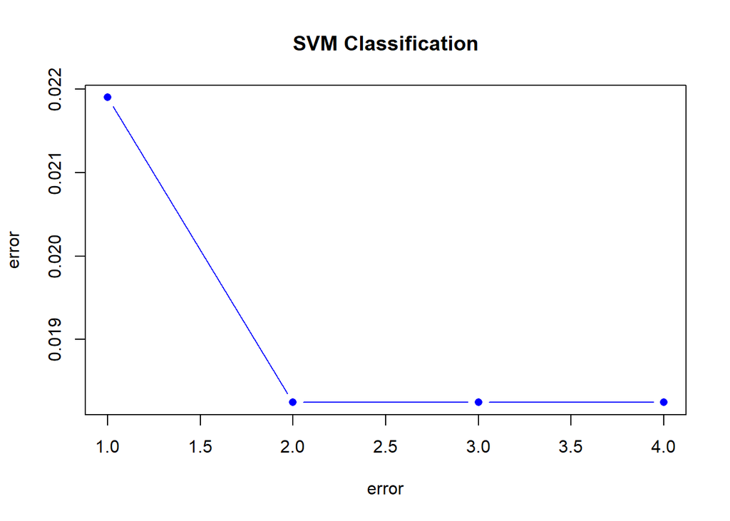

```r
plot(error, type = 'b', main = "SVM Classification", pch = 16,col = 20, xlab = "error")
```

# Problem 2: comparison to random forest

Fit random forest classifier on the entire banknote authentication dataset with default parameters. *The model reports a confusion matrix.* From the report you can Calculate the misclassification error.

– Why the calculated error above confusion matrix represents an estimated test_err? (as opposed to train) error of the procedure.  
– Compare resulting test error to that for support vector classifier in problem 1

```r
rf.bank <- randomForest(Class~.,data=bank.N)
rf.bank
```

```
##
## Call:
##  randomForest(formula = Class ~ ., data = bank.N)
##                Type of random forest: classification
##                      Number of trees: 500
## No. of variables tried at each split: 2
##
##         OOB estimate of  error rate: 0.66%
## Confusion matrix:
##     0   1 class.error
## 0 755   7 0.009186352
## 1   2 608 0.003278689
```

```r
m.pred <- predict(rf.bank,bank.N)
c_mat <- table(m.pred, bank.N$Class)

accuracy <- sum(diag(c_mat))/sum(c_mat)
error <- 1-accuracy
error
```

```
## [1] 0
```

# Problem 3: Comparison to cross-validation tuned KNN predictor

Use `tune.knn()` from the library `e1071` on the entire dataset to determine optimal `k` for k-NN classifier. Setup resampling procedure similar to problem 1 while 1) split banknote authentication dataset into training and test, 2) Using `tune.knn()` on training data to determine optimal `k`, and 3) use `k` estimated by `tune.knn()` to make KNN classifications on test data.

```r
knn_tune <- tune.knn(bank.N_tr[,-5], bank.N_tr[,5], k = 1:25, tunecontrol = tune.control(sampling = "cross"))
summary(knn_tune)
```

```
##
## Parameter tuning of 'knn.wrapper':
##
## - sampling method: 10-fold cross validation
##
## - best parameters:
##  k
##  8
##
## - best performance: 0
##
## - Detailed performance results:
##     k        error  dispersion
## 1   1 0.0009090909 0.002874798
## 2   2 0.0009090909 0.002874798
## 3   3 0.0009090909 0.002874798
## 4   4 0.0009090909 0.002874798
## 5   5 0.0009090909 0.002874798
## 6   6 0.0009090909 0.002874798
## 7   7 0.0009090909 0.002874798
## 8   8 0.0000000000 0.000000000
## 9   9 0.0009090909 0.002874798
## 10 10 0.0000000000 0.000000000
## 11 11 0.0000000000 0.000000000
## 12 12 0.0027439533 0.006182626
## 13 13 0.0036530442 0.007701394
## 14 14 0.0036530442 0.006398906
## 15 15 0.0054795663 0.007701419
## 16 16 0.0054795663 0.007701419
## 17 17 0.0072977481 0.007201706
## 18 18 0.0072977481 0.007201706
## 19 19 0.0072977481 0.007201706
## 20 20 0.0072977481 0.007201706
## 21 21 0.0072977481 0.007201706
## 22 22 0.0072977481 0.007201706
## 23 23 0.0072977481 0.007201706
## 24 24 0.0072977481 0.007201706
## 25 25 0.0072977481 0.007201706
```

Report and discuss test errors from this procedure and selected values of `k`. Compare the selected `k` test_err to those for support vector classifier (problem 1) and randomForest (problem 2).

```r
knn.fit <- knn(train=bank.N_tr, test=bank.N_ts, cl=bank.N_tr_f.tor, k=2)

c_mat <- table(bank.N_ts_f.tor, knn.fit)
c_mat
```

```
##                knn.fit
## bank.N_ts_f.tor   0   1
##               0 150   0
##               1   0 124
```

```r
accuracy <- sum(diag(c_mat))/sum(c_mat)
error <- 1- accuracy
error
```

```
## [1] 0
```

# Problem 4: SVM with radial kernel

## Sub-problem 4a: impact of `gamma` on classification surface

*Plot* SVM model fit to the banknote authentication dataset using (for the ease of plotting) *only variance and skewness* as predictors variables, `kernel="radial"`, `cost=1` and `gamma=1` (see ISLR Ch.9.6.2 for an example of that done with a simulated dataset). You should be able to see in the resulting plot the magenta-cyan classification boundary as computed by this model. Produce the same kinds of plots using 0.01 and 100 as values of `gamma` also. Compare classification boundaries between these three plots and describe how they are impacted by the change in the value of `gamma`. Can you trace it back to the role of `gamma` in the equation introducing it with the radial kernel in ISLR?

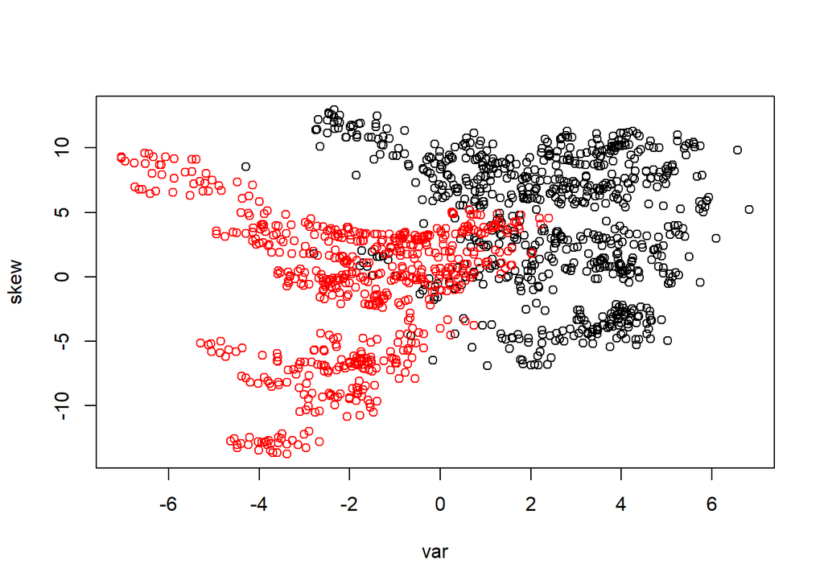

```r
bank.N_data <- cbind(var = bank.N$Var.W, skew = bank.N$Skew.W)
bank_dat <- data.frame(bank.N_data, Class = as.factor(bank.N$Class))

plot(bank.N_data, col = bank.N$Class)
```

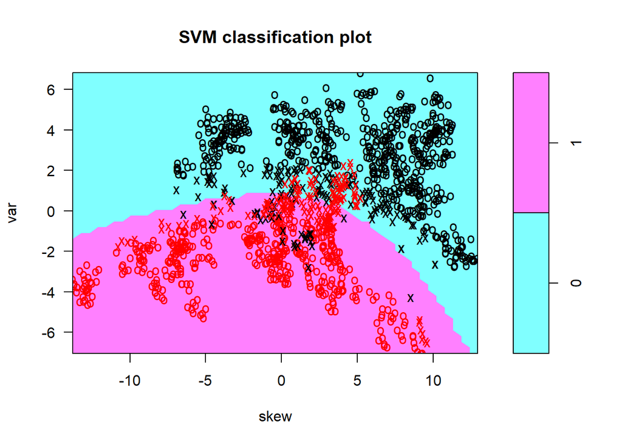

```r
svm.fit = svm(Class ~ ., data = bank_dat, kernel ="radial", gamma=0.1, cost=1)
plot(svm.fit, bank_dat)
```

```r
summary(svm.fit)
```

```
##
## Call:
## svm(formula = Class ~ ., data = bank_dat, kernel = "radial",
##     gamma = 0.1, cost = 1)
##
##
## Parameters:
##    SVM-Type:  C-classification
##  SVM-Kernel:  radial
##        cost:  1
##       gamma:  0.1
##
## Number of Support Vectors:  338
##
##  ( 168 170 )
##
##
## Number of Classes:  2
##
## Levels:
##  0 1
```

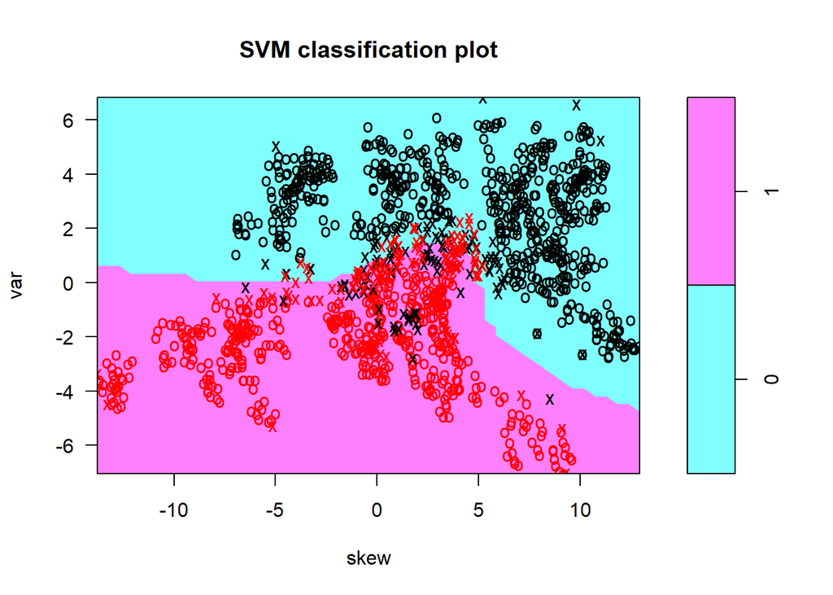

```r
svm.fit = svm(Class ~ ., data = bank_dat, kernel ="radial", gamma=1, cost=1)
plot(svm.fit, bank_dat)
```

```r
summary(svm.fit)
```

```
##
## Call:
## svm(formula = Class ~ ., data = bank_dat, kernel = "radial",
##     gamma = 1, cost = 1)
##
##
## Parameters:
##    SVM-Type:  C-classification
##  SVM-Kernel:  radial
##        cost:  1
##       gamma:  1
##
## Number of Support Vectors:  257
##
##  ( 128 129 )
##
##
## Number of Classes:  2
##
## Levels:
##  0 1
```

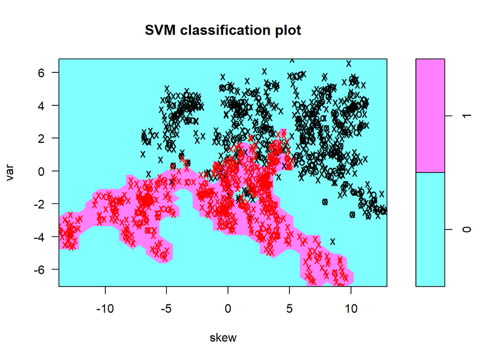

```r
svm.fit = svm(Class ~ ., data = bank_dat, kernel ="radial", gamma=100, cost=1)
plot(svm.fit, bank_dat)
```

```r
summary(svm.fit)
```

```
##
## Call:
## svm(formula = Class ~ ., data = bank_dat, kernel = "radial",
##     gamma = 100, cost = 1)
##
##
## Parameters:
##    SVM-Type:  C-classification
##  SVM-Kernel:  radial
##        cost:  1
##       gamma:  100
##
## Number of Support Vectors:  849
##
##  ( 475 374 )
##
##
## Number of Classes:  2
##
## Levels:
##  0 1
```

We can see from the above plot that there are are fair number of training errors in each plot. Plot for gamma = 100 is very irregular. and probably would over fit the data. PLot for gamma = 01 seems to have least error than plot for gamma = 1.

## Sub-problem 4b: test error for SVM with radial kernel

Setup a reesampling process (similar to Problem 1). 1) split the entire dataset (*use all predictors*) into training and test datasets, 2) use `tune()` function to determine optimal values of `cost=c(1,2,5,10,20)` and `gamma=c(0.01,0.02,0.05,0.1,0.2)` and 3) calculate test error using these values of `cost` and `gamma`. You can start with `cost=c(1,2,5,10,20)` and `gamma=c(0.01,0.02,0.05,0.1,0.2)` as starting ranges to evaluate by `tune()`, Present resulting test error graphically, compare it to that of support vector classifier (with linear kernel), random forest and KNN classifiers. Discuss results of these comparisons.

```r
set.seed(1)
tune.out = tune(svm ,Class~.,data=bank.N ,kernel ="radial",
ranges=list(cost=c(0.1, 1, 10, 100)), gamma =c(0.01,0.02,0.05,0.1,0.2))
summary(tune.out)
```

```
##
## Parameter tuning of 'svm':
##
## - sampling method: 10-fold cross validation
##
## - best parameters:
##  cost
##   100
##
## - best performance: 0
##
## - Detailed performance results:
##    cost      error  dispersion
## 1   0.1 0.05900243 0.016086534
## 2   1.0 0.02405057 0.011923571
## 3  10.0 0.01166825 0.009849837
## 4 100.0 0.00000000 0.000000000
```

# Problem 5: SVM with polynomial kernel

Repeat similar procedure as in problem *4b* for `kernel="polynomial"`. Determine ranges of `coef0`, `degree`, `cost` and `gamma` to be used with `tune()`.  
Present and discuss resulting test error. Compare the result to `linear`, `radial` kernels, `randomForest` and `k-NN`.

```r
tune.out = tune(svm ,Class~.,data=bank.N_tr,kernel ="polynomial",
ranges=list(cost=c(0.1, 1, 10, 100)), gamma =c(0.01,0.02,0.05,0.1,0.2) )
summary(tune.out)
```

```
##
## Parameter tuning of 'svm':
##
## - sampling method: 10-fold cross validation
##
## - best parameters:
##  cost
##   100
##
## - best performance: 0.303211
##
## - Detailed performance results:
##    cost     error dispersion
## 1   0.1 0.4426355 0.04216262
## 2   1.0 0.4426355 0.04216262
## 3  10.0 0.4171393 0.04167024
## 4 100.0 0.3032110 0.03175095
```

```r
svm.fit = svm(Class ~ ., data = bank.N_tr, kernel ="polynomial", gamma=1, cost=100)
summary(svm.fit)
```

```
##
## Call:
## svm(formula = Class ~ ., data = bank.N_tr, kernel = "polynomial",
##     gamma = 1, cost = 100)
##
##
## Parameters:
##    SVM-Type:  C-classification
##  SVM-Kernel:  polynomial
##        cost:  100
##      degree:  3
##       gamma:  1
##      coef.0:  0
##
## Number of Support Vectors:  18
##
##  ( 7 11 )
##
##
## Number of Classes:  2
##
## Levels:
##  0 1
```